# Trail Lecture

Code Tasks

Author

Affiliation

[Dejene](https://scholar.google.com/citations?user=pA-XVOcAAAAJ&hl=en)

[UiT The Arctic University of Norway](https://uit.no/ansatte/dejene.g.kidane)

Published

January 22, 2023

# Task 1: Polynomial regression model

The first task given to work with is polynomial regression model. Polynomial regression model is one of the most well known models in econometrics and they are easy to work with, they can fit varies curves due to their flexibility.

A $k^{th}$ order polynomial model can be given as follows:

$$y = \alpha + \sum_{i=1}^k\beta_i x_i$$

Iterating this model for $i = 1,2,...,k$, we will have the following $k$ polynomial regression models:
$$y = \alpha + \beta_1x^1$$
$$y = \alpha + \beta_1x^1 + \beta_2x^2 \\
...$$
$$y = \alpha + \beta_1x^1 + \beta_2x^2 + ...+\beta_kx^k$$

Let us fit the polynomial regression model given above using a data. I will be using a data scraped from a web. The data I will be using is scraped from a [web-page](https://www.nettavisen.no/skattetall/penger/skattelistene-2022/stor-oversikt-dette-er-snittlonnen-for-ditt-arskull-pa-ditt-postnummer/s/5-95-806984). The table contains data of taxpayers average income and wealth per birth year in Norway.

Now let us start our analysis first by scraping our date from the webpage.

```r
# first load relevant packages and libraries to scrap the data and perform the analysis
rm(list = ls())
library(tidyverse)
library(janitor)
library(lubridate)
library(forecast)
library(quantmod)
library(furrr)
library(tibble)
library(tsibble)
library(mosaic)
#library(fable)
```

Read/scarp data from the web and look at the structure of the data

```r
#browseURL("https://www.nettavisen.no/skattetall/penger/skattelistene-2022/stor-oversikt-dette-er-snittlonnen-for-ditt-arskull-pa-ditt-postnummer/s/5-95-806984")

raw_dataset <- read_csv("https://datawrapper.dwcdn.net/sBuxT/3/dataset.csv")
str(raw_dataset)
```

```
spc_tbl_ [977 × 8] (S3: spec_tbl_df/tbl_df/tbl/data.frame)
 $ birthyr             : num [1:977] 1917 1918 1919 1920 1921 ...
 $ n_taxpayers         : num [1:977] 53 76 162 257 420 ...
 $ income              : num [1:977] 110184 118620 139005 165488 169149 ...
 $ fortune             : num [1:977] 495961 637675 886737 793308 915451 ...
 $ n_millionincome     : num [1:977] 1 0 1 1 2 1 2 3 7 15 ...
 $ n_millionfortune    : num [1:977] 11 19 41 71 128 ...
 $ Andel millioninntekt: chr [1:977] "1.89%" "0.00%" "0.62%" "0.39%" ...
 $ Andel millionformue : chr [1:977] "20.75%" "25.00%" "25.31%" "27.63%" ...
 - attr(*, "spec")=
  .. cols(
  ..   birthyr = col_double(),
  ..   n_taxpayers = col_number(),
  ..   income = col_number(),
  ..   fortune = col_number(),
  ..   n_millionincome = col_number(),
  ..   n_millionfortune = col_number(),
  ..   `Andel millioninntekt` = col_character(),
  ..   `Andel millionformue` = col_character()
  .. )
 - attr(*, "problems")=<externalptr>
```

Here, I consider the share of taxpayers that has wealth over 1 million NOK, measured as percentage points (as $y$- variable), and birth year( as $x$-variable). So, let us clean our data and define our new variables.

```r
dataset <-
  raw_dataset %>%
  clean_names()

dataset <-
  dataset %>%
  filter(birthyr <= 2003)

dataset <-
  dataset %>%
  mutate(share_mill_inc = 100*n_millionincome/n_taxpayers,
         share_mill_wealth = 100*n_millionfortune/n_taxpayers)
#head(dataset)
#tail(dataset)
```

Let us plot birth year against share of taxpayers with million wealth.

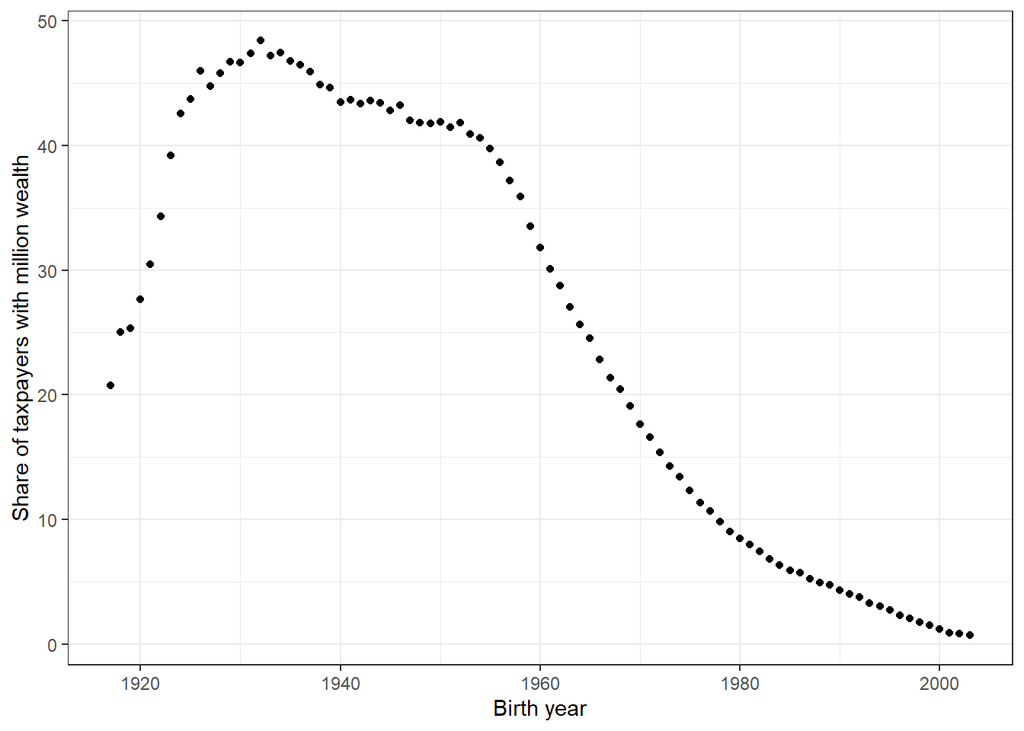

```r
dataset %>%
  ggplot(aes(x=birthyr, y=share_mill_wealth)) +
  geom_point() +
  xlab("Birth year") +
  ylab("Share of taxpayers with million wealth") +
  theme_bw()
```

It is obvious that the plot above is non-linear.

Now let fit our data using the polynomial regression model of degree $k = 1,2,...,12$. And then choose the best model that minimizes the AIC value out of these $12$ regression models.

```r
# First renaming variables(defining the x and y variables)
dataset <- dataset %>%
  select(birthyr,share_mill_wealth) %>%
  rename(x = birthyr,
         y = share_mill_wealth)

#Run for loop to estimate models and store
#model information as output.
k <- c(1:12) # k-th order
# setup
AIC <- data.frame("kth_order" = NA, "AIC" = NA) # empty data frame to store RMSE
RMSE <- data.frame("kth_order" = NA, "RMSE" = NA) # empty data frame to store RMSE

for (i in 1:length(k)) {
  # build models
  model <- lm(y ~ poly(x, k[i]), data = dataset)

  # calculate RMSE and store it for further usage
  RMSE[i, 1] <- k[i] # store k-th order
  RMSE[i, 2] <- sqrt(mean((fitted(model) - dataset$y)^2))
  AIC[i,1] <- k[i] # store k-th order
  AIC[i,2] <- AIC(model) # store k-th order
}
# output from the loop
output <- data.frame(RMSE, AIC=AIC$AIC)
output
```

```
   kth_order      RMSE      AIC
1          1 8.2559956 620.1988
2          2 6.4926059 580.3908
3          3 2.1238818 387.9600
4          4 1.8790063 368.6446
5          5 1.8783339 370.5823
6          6 1.4134256 323.1021
7          7 1.3094836 311.8114
8          8 1.0304815 272.1199
9          9 0.6643752 197.7453
10        10 0.6449433 194.5801
11        11 0.6239779 190.8299
12        12 0.6235005 192.6967
```

Then choose the best model based on AIC.

```r
#best model based on AIC
output%>%
  filter(AIC==min(AIC))
```

```
  kth_order      RMSE      AIC
1        11 0.6239779 190.8299
```

Estimate the best model, and check AIC and RMSE.

```r
# the poly 11 model is the smallest
fit <- lm(y ~ poly(x, 11 , raw=FALSE), data = dataset)
AIC(fit)
```

```
[1] 190.8299
```

```r
#plotModel(fit)

# check (calculate the RMSE of the best model)
dataset <- dataset %>% mutate(y_hat=predict(fit))
dataset %>% summarise(RMSE=sqrt(mean((y-y_hat)^2)))
```

```
# A tibble: 1 × 1
   RMSE
  <dbl>
1 0.624
```

```r
library(Metrics)
RMSE <- round(rmse(dataset$y, dataset$y_hat),4)
RMSE #the same as above
```

```
[1] 0.624
```

Make a plot of the “best” model from above and include data points. Restrict the observations on the plot and the fitted model such that **birth year** is in the interval $\{1925 \leq x \leq 2000\}.$ Add the **RMSE** to the plot.

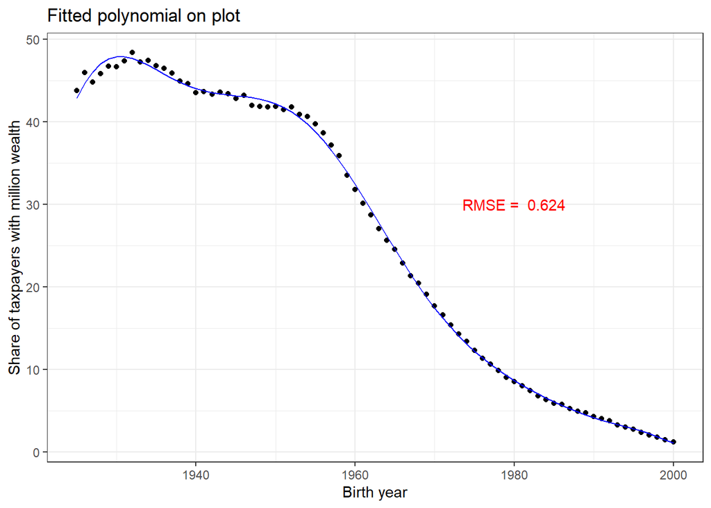

```r
# plot the best model
library(ggrepel)
dataset %>%
  mutate(predicted=predict(fit)) %>%
  filter(x>= 1925 & x <= 2000) %>%
  ggplot(aes(x=x,y=y)) +
  geom_point() +
  geom_line(aes(x=x,y=predicted), col="blue") +
  xlab("Birth year") +
  ylab("Share of taxpayers with million wealth") +
  annotate(geom="text", x=1980, y=30, label=paste("RMSE = ", RMSE), color="red") +
  ggtitle("Fitted polynomial on plot") +
  theme_bw()
```

# Task 2- Time series analsysis - accuracy in forecasting

Forecasting is a form of prediction. In time series analysis we often want to predict something in the future on the basis of what we have observed in the past. The evaluation of the accuracy of our prediction is an important part of model evaluation. Poor accuracy means that our prediction will be scarcely helpful.

**Autoregressive integrated moving average(ARIMA) models** is one of the most common time series model used for forecasting. Given time series data $X_t$ where $t$ is an integer index and the $X_t$ are real numbers, ARIMA(p,d,q) model can be given as follows:

$$X_t = a_1X_{t-1} + ...+a_pX_{t-p} + \epsilon_t + b_1\epsilon_{t-1}+...+b_q\epsilon_{t-q}$$
where $a_i$ are the parameters of the autoregressive part of the model , $b_i$ are the parameters of the moving average part and the $\epsilon_t$ are error terms. The error terms $\epsilon_t$ are generally assumed to be independent, identically distributed variables sampled from a normal distribution with zero mean.

In some cases where data show evidence of non-stationarity in the sense of mean, differencing of the time-series is applied to eliminate the non-stationarity. The difference is taken d times until the original series becomes stationary.The d is then called the “integrated” part of the ARIMA model.Furthermore, when the time-series shows seasonality,the seasonal-differencing could be applied to eliminate the seasonal component.

The exercise here here is to model stock prices from Exxon Mobile Corporation (XOM), traded at NYSE. The XOM stock prices is obtained from [The Yahoo! Fiance site](https://finance.yahoo.com/quote/XOM?p=XOM&.tsrc=fin-srch&guccounter=1). Two model specifications of a non-seasonal **ARIMA** models are estimated. In model-1, a univariate ARIMA model is estimated. In model-2, the Brent Crude Oil Price is used as an explanatory variable. The Brent Crude Oil Price is obtained from [FRED](https://fred.stlouisfed.org/series/DCOILBRENTEU).

```r
# Import XOM data from yahoo finance

# XOM
loadSymbols("XOM", src="yahoo" )
```

```
[1] "XOM"
```

```r
xom_data <- XOM
head(xom_data)
```

```
           XOM.Open XOM.High XOM.Low XOM.Close XOM.Volume XOM.Adjusted
2007-01-03    76.26    76.27   73.51     74.11   30510700     42.43664
2007-01-04    73.85    73.90   72.21     72.72   31046600     41.64070
2007-01-05    72.45    73.38   72.22     73.24   24671500     41.93846
2007-01-08    73.88    74.25   71.85     72.65   25981900     41.60063
2007-01-09    71.85    72.84   71.44     72.09   27039900     41.27995
2007-01-10    71.81    73.11   70.64     70.99   30572000     40.65008
```

```r
class(xom_data) # this is xts or zoo
```

```
[1] "xts" "zoo"
```

```r
# convert it to a data frame
xom.df <- as.data.frame(xom_data)  #data frame
class(xom.df)
```

```
[1] "data.frame"
```

```r
head(xom.df)
```

```
           XOM.Open XOM.High XOM.Low XOM.Close XOM.Volume XOM.Adjusted
2007-01-03    76.26    76.27   73.51     74.11   30510700     42.43664
2007-01-04    73.85    73.90   72.21     72.72   31046600     41.64070
2007-01-05    72.45    73.38   72.22     73.24   24671500     41.93846
2007-01-08    73.88    74.25   71.85     72.65   25981900     41.60063
2007-01-09    71.85    72.84   71.44     72.09   27039900     41.27995
2007-01-10    71.81    73.11   70.64     70.99   30572000     40.65008
```

Import the Brent oil data from FRED

```r
#oil
loadSymbols("DCOILBRENTEU", src="FRED")
```

```
[1] "DCOILBRENTEU"
```

```r
#getSymbols("DCOILBRENTEU", src = "FRED",from ="2010-01-04", to = "2022-01-13")
oil_data <- DCOILBRENTEU
class(oil_data) # this is xts or zoo
```

```
[1] "xts" "zoo"
```

```r
# convert it to a data frame
oil_df <- as.data.frame(oil_data)
class(oil_df)
```

```
[1] "data.frame"
```

```r
head(oil_df)
```

```
           DCOILBRENTEU
1987-05-20        18.63
1987-05-21        18.45
1987-05-22        18.55
1987-05-25        18.60
1987-05-26        18.63
1987-05-27        18.60
```

## Data Wrangling

Calculate the monthly average of xom and brent oil data.

```r
# calculate the monthly arithmetic average of xom price data.
# Also calculate the weighted average of xom, using volume traded as a weight.
xom <- xom.df %>%
  mutate(Date = ymd(rownames(xom.df))) %>% # create a date variable
  filter(Date >="2010-01-04",Date<"2023-01-01") %>%  # filter data only between the specified dates
  mutate(year = year(Date), #create the variables called year from the date variable
         month = month(Date),
         day = day(Date)) %>%
  group_by(year,month) %>%
  # calculate arithmetic average, and weighted average using
  #volume as a weight.
  summarise(xom_monthly_art= mean(XOM.Adjusted),
            xom_monthly_wt=sum(XOM.Adjusted*XOM.Volume)/sum(XOM.Volume)) %>%
  mutate(date = make_date(year,month,1)) %>% as_tibble() %>%  #
  select(date, xom_monthly_wt)

#output
xom
```

```
# A tibble: 156 × 2
   date       xom_monthly_wt
   <date>              <dbl>
 1 2010-01-01           41.2
 2 2010-02-01           39.9
 3 2010-03-01           40.7
 4 2010-04-01           41.8
 5 2010-05-01           38.6
 6 2010-06-01           37.1
 7 2010-07-01           36.2
 8 2010-08-01           37.4
 9 2010-09-01           38.0
10 2010-10-01           40.3
# … with 146 more rows
```

```r
# calculate the monthly arithmetic average of oil price data.
oil <- oil_df %>%
  # create a date variable from the rownames of the dataframe
  mutate(Date = ymd(rownames(oil_df))) %>%
  # filter the data only between 2010-01-04 and 2022-12-30
  # since our package imports all data from 1987-05-20
  filter(Date>="2010-01-04",Date<"2023-01-01") %>%
  mutate(year = year(Date),
         month = month(Date),
         day = day(Date)) %>%
  group_by(year,month) %>%
  # calculate the monthly arithmetic average
  summarise(oil_monthly= mean(DCOILBRENTEU, na.rm = TRUE)) %>%
  mutate(date = make_date(year,month,1)) %>%as_tibble() %>%
  select(date,oil_monthly)
#output
oil
```

```
# A tibble: 156 × 2
   date       oil_monthly
   <date>           <dbl>
 1 2010-01-01        76.2
 2 2010-02-01        73.8
 3 2010-03-01        78.8
 4 2010-04-01        84.8
 5 2010-05-01        75.9
 6 2010-06-01        74.8
 7 2010-07-01        75.6
 8 2010-08-01        77.0
 9 2010-09-01        77.8
10 2010-10-01        82.7
# … with 146 more rows
```

```r
#Put/merge the xom and oil data as one data frame, and rename variables.

dframe <- xom %>% left_join(oil)

dframe <- dframe%>%
  rename(exxon=xom_monthly_wt,
         brent = oil_monthly)
head(dframe)
```

```
# A tibble: 6 × 3
  date       exxon brent
  <date>     <dbl> <dbl>
1 2010-01-01  41.2  76.2
2 2010-02-01  39.9  73.8
3 2010-03-01  40.7  78.8
4 2010-04-01  41.8  84.8
5 2010-05-01  38.6  75.9
6 2010-06-01  37.1  74.8
```

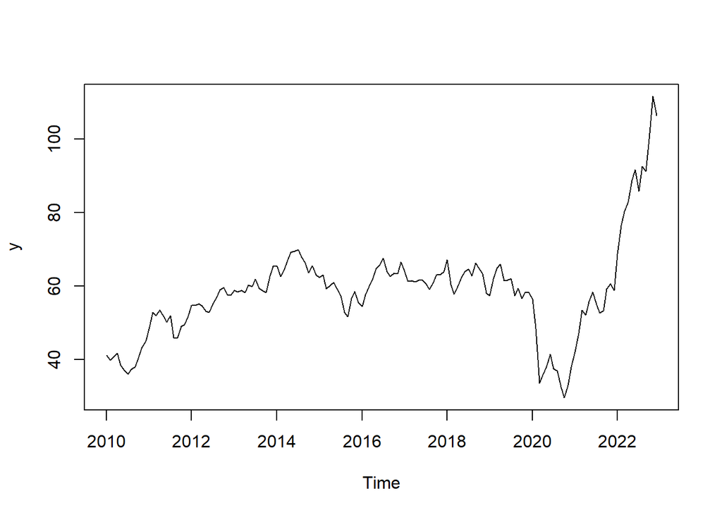

```r
# define the variables as time series objects.
# assign them as y and x variables, and time series plots.
y <-
  dframe %>%
  mutate(y=exxon,
         year=year(date)) %>%
  filter(year <= 2022) %>%
  select(y) %>%
  ts(., frequency = 12, start = c(2010, 1))

plot(y)
```

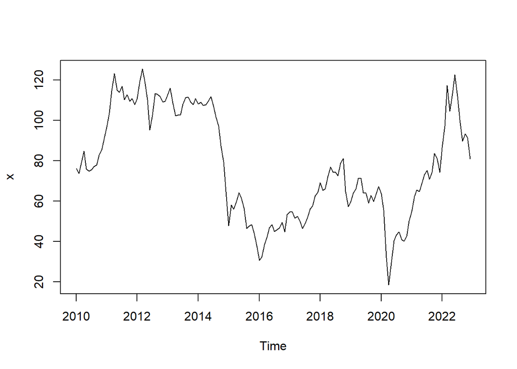

```r
x <-
  dframe %>%
  mutate(x=brent,
         year=year(date)) %>%
  filter(year <= 2022) %>%
  select(x) %>%
  ts(., frequency = 12, start = c(2010, 1))

plot(x)
```

```r
#Split the x and y variables as train and test data
y_train <- window(y, end=c(2022, 6))
y_test <- window(y, start=c(2022, 7))

x_train <- window(x, end=c(2022, 6))
x_test <- window(x, start=c(2022, 7))
```

## Estimation

### using builtin function

Estimate ARIMA model using *auto.arima** function from the *forecast* package

```r
# AIC in train, Model 2, slightly better & a simple structure
# Model 1
auto.arima(y_train)
```

```
Series: y_train
ARIMA(0,1,1)

Coefficients:
        ma1
      0.302
s.e.  0.078

sigma^2 = 8.708:  log likelihood = -372.21
AIC=748.41   AICc=748.5   BIC=754.42
```

```r
forecast::accuracy(auto.arima(y_train))
```

```
                    ME     RMSE      MAE       MPE     MAPE     MASE
Training set 0.2612599 2.931257 2.177354 0.2932626 4.098518 0.232827
                     ACF1
Training set -0.005313483
```

```r
# Model 2
auto.arima(y_train, xreg = x_train)
```

```
Series: y_train
Regression with ARIMA(0,1,0) errors

Coefficients:
           x
      0.2869
s.e.  0.0320

sigma^2 = 6.182:  log likelihood = -346.63
AIC=697.27   AICc=697.35   BIC=703.28
```

```r
forecast::accuracy(auto.arima(y_train, xreg = x_train))
```

```
                    ME     RMSE      MAE      MPE     MAPE      MASE      ACF1
Training set 0.2478741 2.469754 1.927975 0.251294 3.562849 0.2061607 0.1006569
```

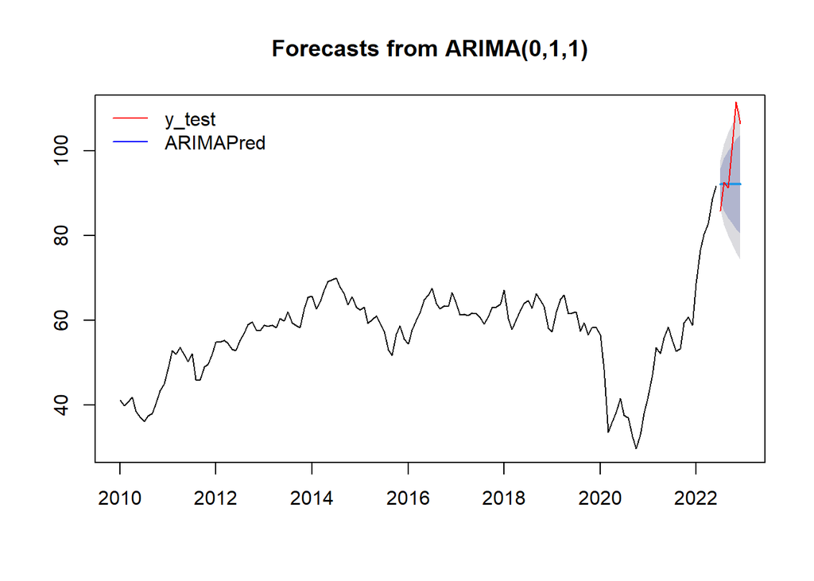

```r
#Model 1
# plot of the prediction and of the test set
arimaMod <- auto.arima(y_train, stepwise=FALSE, approximation=FALSE)
arimaMod.Fr <-forecast(arimaMod,h=6)

# plot of the prediction and of the test set
plot(arimaMod.Fr)
lines(y_test, col="red")
legend("topleft",lty=1,bty = "n",col=c("red","blue"),c("y_test","ARIMAPred"))
```

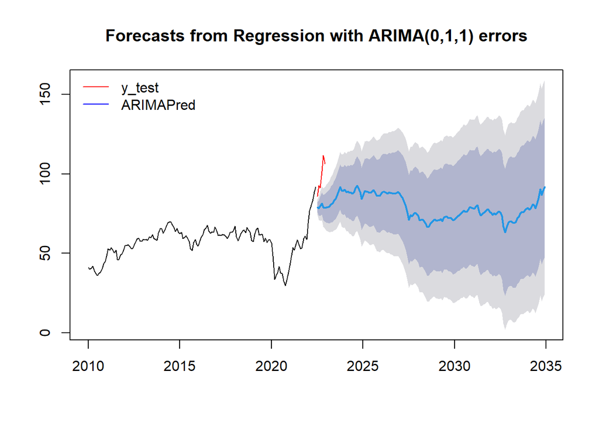

```r
#Model 2
# plot of the prediction and of the test set
arimaMod <- auto.arima(y_train, xreg = x_train,stepwise=FALSE, approximation=FALSE)
arimaMod.Fr <-forecast(arimaMod,xreg = x_train,h=6)

# plot of the prediction and of the test set
plot(arimaMod.Fr)
lines(y_test, col="red")
legend("topleft",lty=1,bty = "n",col=c("red","blue"),c("y_test","ARIMAPred"))
```

### using defined ARIMA models

```r
# prepare

# From a forecast object, define point estimate,
# confidence interval and then put all as one data frame
to_tibble <- function(forecast_object){
  point_estimate <-
    forecast_object$mean %>%
    as_tsibble() %>%
    rename(point_estimate = value,
           date = index)

  upper <-
    forecast_object$upper %>%
    as_tsibble() %>%
    pivot_wider(names_from = "key",
                values_from = "value") %>%
    rename(date = index,
           upper80 = `80%`,
           upper95 = `95%`)

  lower <- forecast_object$lower %>%
    as_tsibble() %>%
    pivot_wider(names_from = "key",
                values_from = "value") %>%
    rename(date = index,
           lower80 = `80%`,
           lower95 = `95%`)

  reduce(list(point_estimate, upper, lower), full_join)
}
```

```r
#create a matrix of all desired orders
hyper_parameters_df <- expand_grid(p = 0:10, d = 0:1, q=0:10)

#The split() function in R can be used to split data into groups
hyper_parameters_df_list <- split(hyper_parameters_df, seq(nrow(hyper_parameters_df)))
# it is a list, but its elements are tibbles

hyper_parameters_df <- hyper_parameters_df_list %>% map(lift(c))
# it is also a list, but its elements are vectors

orderdf <- tibble("order" = hyper_parameters_df)
# it is a tibble whose elements are a vector of elements three compo

nrows <- nrow(orderdf) # number of rows
#glimpse(orderdf)
#View(orderdf)
```

#### Model 1- Univariate ARIMA model

In model-1, $y$, which is the the monthly average stock prices for xom is used as a dependent variable.

```r
# Model 1
tic <- Sys.time()
models_df <-
  orderdf %>%
  mutate(models = future_map(.x = order,
                             ~possibly(Arima, otherwise = NULL)(y_train, order = .x))) # Model 1

toc <- Sys.time() - tic
toc
```

```
Time difference of 1.012884 mins
```

```r
models_df <-
  models_df %>%
  mutate(forecast = map(models, ~possibly(forecast, otherwise = NULL)(., h = 6))) %>% # Model 1
  mutate(point_forecast = map(forecast, ~.$`mean`)) %>%
  mutate(true_value = rerun(nrows, y_test)) %>%
  mutate(rmse = map2_dbl(point_forecast, true_value, ~sqrt(mean((as.vector(.x) - as.vector(.y))^2))))
```

```r
best_model <-models_df %>%filter(rmse == min(rmse, na.rm = TRUE))
best_model$order
```

```
$`236`
 p  d  q
10  1  4
```

```r
best_model_forecast <- to_tibble(best_model$forecast[[1]])
best_model_forecast
```

```
# A tsibble: 6 x 6 [1M]
      date point_estimate upper80 upper95 lower80 lower95
     <mth>          <dbl>   <dbl>   <dbl>   <dbl>   <dbl>
1 2022 Jul           92.7    96.6    98.6    88.9    86.9
2 2022 Aug           95.3   102.    105.     89.0    85.6
3 2022 Sep           96.5   105.    109.     88.3    84.0
4 2022 Oct           96.2   106.    111.     86.5    81.4
5 2022 Nov           98.0   109.    115.     87.1    81.3
6 2022 Dec          100.    112.    119.     87.7    81.2
```

```r
fit1 <- forecast::Arima(y_train, order=unlist(best_model$order)) # Model 1
summary(fit1)
```

```
Series: y_train
ARIMA(10,1,4)

Coefficients:
          ar1      ar2      ar3     ar4      ar5     ar6     ar7     ar8
      -0.6300  -0.3936  -0.0661  0.4948  -0.0319  0.0937  0.1389  0.0775
s.e.   0.6997   0.8215   0.7125  0.4062   0.1830  0.1249  0.1585  0.1826
          ar9    ar10     ma1     ma2     ma3      ma4
      -0.0389  0.0949  0.9519  0.6301  0.1978  -0.4691
s.e.   0.1517  0.1032  0.7000  1.0399  0.9928   0.6436

sigma^2 = 8.921:  log likelihood = -367.93
AIC=765.86   AICc=769.47   BIC=810.92

Training set error measures:
                    ME     RMSE      MAE       MPE     MAPE      MASE
Training set 0.2276764 2.833557 2.148433 0.2886381 4.037307 0.2297345
                     ACF1
Training set -0.005696644
```

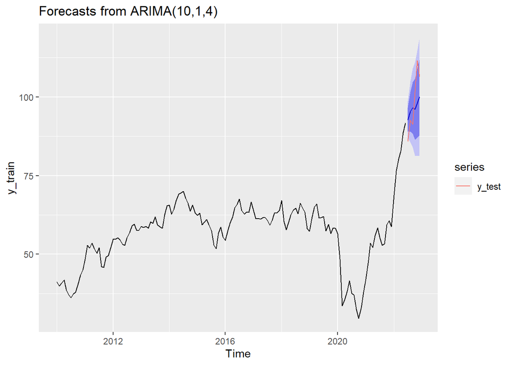

```r
fcst1 <- forecast::forecast(fit1, h=6) # Model 1

autoplot(fcst1) + autolayer(y_test)
```

```r
# Apply fitted model to later data
fit_test1 <- forecast::Arima(window(y, start=c(2022,7), model=fit1))
```

```r
# Forecast accuracy measures on the log scale.
# in-sample one-step forecasts.
forecast::accuracy(fit1)
```

```
                    ME     RMSE      MAE       MPE     MAPE      MASE
Training set 0.2276764 2.833557 2.148433 0.2886381 4.037307 0.2297345
                     ACF1
Training set -0.005696644
```

```r
# out-of-sample one-step forecasts.
forecast::accuracy(fit_test1)
```

```
                        ME     RMSE      MAE        MPE     MAPE MASE      ACF1
Training set -1.894781e-14 9.037603 8.316715 -0.8480463 8.520607  NaN 0.4892863
```

```r
# out-of-sample multi-step forecasts
forecast::accuracy(forecast(fit1, h=6, lambda=NULL), window(y,start=c(2022,7))) # Model 1
```

```
                    ME     RMSE      MAE       MPE     MAPE      MASE
Training set 0.2276764 2.833557 2.148433 0.2886381 4.037307 0.2297345
Test set     1.7577407 7.497990 6.714183 1.1349488 6.710482 0.7179556
                     ACF1 Theil's U
Training set -0.005696644        NA
Test set      0.446838333 0.9653076
```

#### Model 2- Bivaraite ARIMA Model

In model-2, $y$, which is the the monthly average stock prices for xom is used as a dependent variable, while the the monthly average of Brent Crude Oil Prices is used as $x-$variable.

```r
# Model 2
tic <- Sys.time()
models_df <-
  orderdf %>%
  mutate(models = future_map(.x = order,
                            ~possibly(Arima, otherwise = NULL)(y_train, xreg=x_train, order = .x))) # Model 2

toc <- Sys.time() - tic
toc
```

```
Time difference of 1.462818 mins
```

```r
models_df <-
  models_df %>%
  mutate(forecast = map(models, ~possibly(forecast, otherwise = NULL)(., xreg=x_test, h = 6))) %>% # Model 2
  mutate(point_forecast = map(forecast, ~.$`mean`)) %>%
  mutate(true_value = rerun(nrows, y_test)) %>%
  mutate(rmse = map2_dbl(point_forecast, true_value, ~sqrt(mean((as.vector(.x) - as.vector(.y))^2))))

best_model <-
  models_df %>%
  filter(rmse == min(rmse, na.rm = TRUE))

best_model$order
```

```
$`66`
 p  d  q
 2  1 10
```

```r
best_model_forecast <- to_tibble(best_model$forecast[[1]])
```

```r
fit2 <- forecast::Arima(y_train, xreg=x_train, order=unlist(best_model$order)) # Model 2
summary(fit2)
```

```
Series: y_train
Regression with ARIMA(2,1,10) errors

Coefficients:
         ar1      ar2      ma1     ma2     ma3      ma4     ma5     ma6     ma7
      0.2636  -0.9389  -0.1263  0.9544  0.2248  -0.0814  0.1112  0.0425  0.0399
s.e.  0.0546   0.0436   0.1016  0.1220  0.1196   0.1216  0.1270  0.1296  0.1190
         ma8     ma9    ma10       x
      0.0586  0.1341  0.0398  0.2609
s.e.  0.1088  0.0923  0.1090  0.0300

sigma^2 = 6.059:  log likelihood = -341.37
AIC=710.73   AICc=713.87   BIC=752.79

Training set error measures:
                    ME     RMSE      MAE       MPE     MAPE      MASE
Training set 0.2042177 2.343842 1.785068 0.2374631 3.288877 0.1908795
                    ACF1
Training set -0.01052938
```

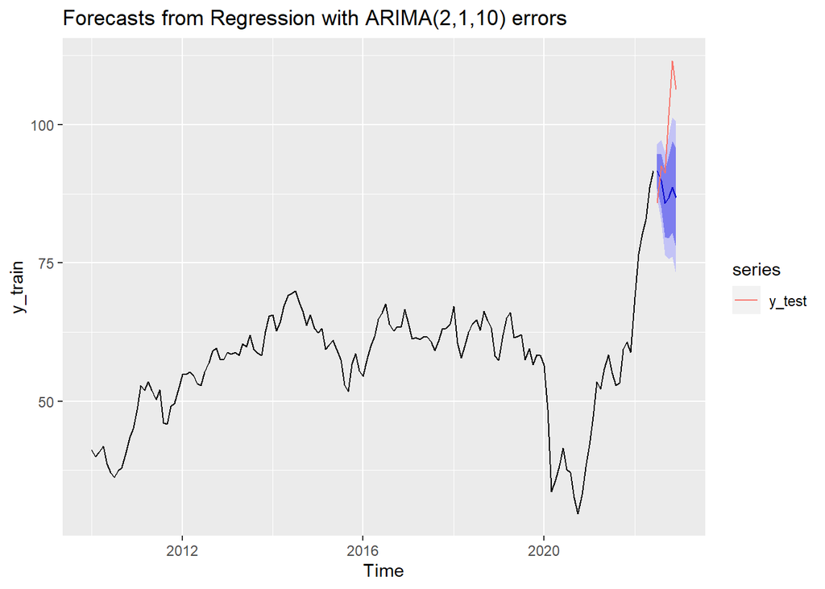

```r
fcst2 <- forecast::forecast(fit2, xreg=x_test, h=6) # Model 2
autoplot(fcst2) + autolayer(y_test)
```

```r
# Apply fitted model to later data
fit_test2 <- forecast::Arima(window(y, start=c(2022,7), model=fit2))
```

```r
# Forecast accuracy measures on the log scale.
# in-sample one-step forecasts.
forecast::accuracy(fit2)
```

```
                    ME     RMSE      MAE       MPE     MAPE      MASE
Training set 0.2042177 2.343842 1.785068 0.2374631 3.288877 0.1908795
                    ACF1
Training set -0.01052938
```

```r
# out-of-sample one-step forecasts.
forecast::accuracy(fit_test2)
```

```
                        ME     RMSE      MAE        MPE     MAPE MASE      ACF1
Training set -1.894781e-14 9.037603 8.316715 -0.8480463 8.520607  NaN 0.4892863
```

```r
# out-of-sample multi-step forecasts
forecast::accuracy(forecast(fit2, xreg=x_test, h=6, lambda=NULL), window(y,start=c(2022,7))) # Model 2
```

```
                    ME      RMSE       MAE       MPE      MAPE      MASE
Training set 0.2042177  2.343842  1.785068 0.2374631  3.288877 0.1908795
Test set     9.9588916 14.135908 11.893370 9.2917344 11.545398 1.2717723
                    ACF1 Theil's U
Training set -0.01052938        NA
Test set      0.51661233  1.903635
```

# Findings of the ARIMA models

It is clear from the plots that the prediction based on the univariate ARMA model produces a good forecast of the series compared to the bivariate model.

The issue in polynomial modeling is multicollinarity The issue in time series modeling is autocorrelation(non-stationarity)